# ClassifyITS Pipeline Overview

## Introduction

This vignette shows how to use ClassifyITS to assign taxonomy to fungal ITS sequences, visualize results, and review QC outputs. Summary plots and tables are generated here, and are also compiled into a multi-page PDF for easy sharing.

## Run the Pipeline

Assuming you have downloaded and installed the ClassifyITS package, you can run the taxonomy assignment pipeline using the example BLAST and FASTA files included in the package. Replace these paths with your own files as needed.

For information on generating the required BLAST and FASTA files, see the [README]

```r
library(ClassifyITS)

# Paths to example BLAST and FASTA files in the package (replace with your own paths)
blast_path <- system.file("extdata", "example_BLAST.tsv", package = "ClassifyITS")
fasta_path <- system.file("extdata", "example_FASTA.fasta", package = "ClassifyITS")

# Run the assignment pipeline, the only required inputs are the BLAST file and the representative sequence FASTA file
results <- ITS_assignment(
  blast_file = blast_path,
  rep_fasta  = fasta_path
)
```

```
## Parsing taxonomy from stitle column...
```

## Inspect Console Outputs

The pipeline will print:

```
Taxonomy assignments exported to outputs/initial_assignments.csv
Saved taxonomy graphics and summary tables to PDF in outputs
```

If any OTUs failed quality control steps or did not receive an assignment, a warning will be displayed:

```
Warning message:
In ITS_assignment(blast_file = blast_path, rep_fasta = fasta_path) :
  Warning: X of your X FASTA sequences failed QC and could not be classified using this pipeline due to missing or poor BLAST results.
```

This is normal in large datasets: a small number of OTUs often fail QC or don’t receive a taxonomy assignment at certain levels. See the PDF out for an exact breakdown of how many OTUs passed each step in the pipeline. The CSV taxonomic outputs also notes all OTUs that failed QC.

This warning is meant to remind users to review the outputs and consider manual curation for unassigned OTUs, especially if they are abundant or of particular interest in downstream analyses. Or perhaps discard these OTUs if they are rare and likely spurious. The pipeline provides the information needed to make informed decisions about how to handle these cases in your dataset.

The most common reason for an OTU to fail QC is that the BLAST file did not contain any BLAST results for that OTU.

## Visualize Summary Plots

Below are the main summary plots. These are also compiled together into `outputs/combined_taxonomy_graphics.pdf`.

```
## Saved taxonomy graphics and summary tables to PDF in outputs
```

### Alignment length histogram

This figure shows the distribution of BLAST alignment lengths across user specified BLAST results. One of the essential qualiy control steps in ClassifyITS is to filter out BLAST hits that are too short, as these may not provide reliable taxonomic information. The histogram includes vertical lines indicating the median BLAST alignment length, the cutoff length applied for filtering, and the mean length of the representative sequences in the FASTA file. The default alignment cutoff is 0.6 of the Median BLAST Alignment length. This can also be adjusted with the parameter `cutoff_fraction` in the `plot_alignment_hist` function. See the quick start for details on how to adjust this parameter.

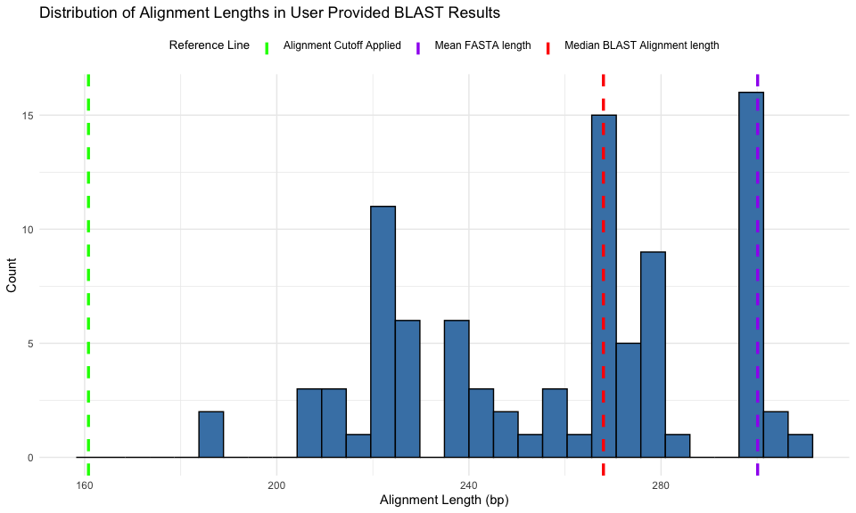

### Assignment summary bar chart

ClassifyITS is meant to assign taxonomy to studies targeting fungi, as ITS fungal primers occasionally pick up other reads (plants, alage, etc.) but these taxa are generally discarded in downstream analyses. The first taxonomic step in ClassifyITS is to apply kingdom specific cutoffs to the BLAST results. The taxonomic pipeline then proceeds to assign taxonomy to reads in kingdom fungi at the phylum, class, order, family, genus, and species levels. The assignment bar chart shows the number of fungal OTUs that received an assignment (as in not Unclassified) at each taxonomic level. This is a useful figure to quickly assess how many OTUs were successfully classified at each taxonomic level. Note that it is common for the number of OTUs assigned to drop at each taxonomic level, especially at the species level where many OTUs may not receive a confident assignment. This figure can help identify if there are any unexpected drops in assignment success that may warrant further investigation or manual review.

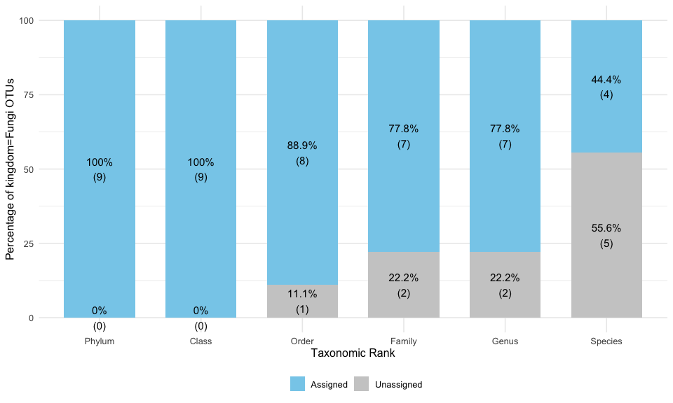

### Phylum level stacked bar chart

This figure provides a quick summary of the taxonomic composition of the dataset at the phylum level. Importantly, this is the count of OTUs not the relative abundance of each phylum in the OTU table.

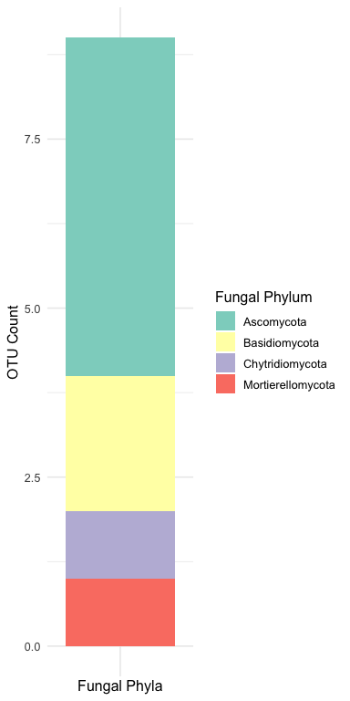

## Review Tabular Outputs

### Step Summary Table

A breakdown of how many OTUs passed each step in the pipeline, including QC failures and taxonomic assignments at each level. This is a useful table to quickly assess the overall success of the taxonomy assignment process and identify any steps where a large number of OTUs may have failed or not received an assignment.

| Step | Count |
| --- | --- |
| # of OTUs in Representative Sequence | 11 (100%) |
| # of OTUs pass quality check | 10 (90.9%) |
| OTUs assigned to fungal kingdom | 9 (81.8%) |
| OTUs assigned to fungal phylum | 9 (81.8%) |
| OTUs assigned to fungal class | 9 (81.8%) |
| OTUs assigned to fungal order | 8 (72.7%) |

### Unique Taxa Counts Table

This table shows the number of unique taxa assigned at each taxonomic level, but only for OTUs that were classified as kingdom Fungi. This is a useful summary to understand the diversity of taxa represented in the dataset at each taxonomic level.

|  | Rank | Unique Count |
| --- | --- | --- |
| phylum | Phylum | 4 |
| class | Class | 7 |
| order | Order | 8 |
| family | Family | 7 |
| genus | Genus | 7 |
| species | Species | 4 |

## PDF Output

> The PDF file [`outputs/combined_taxonomy_graphics.pdf`] contains all the summary plots and tables for concise review.

## Conclusion

ClassifyITS produces summary visualizations and tables for every run. A background rate of failed QC is expected. Additionally, ClassifyITS is designed to be conservative in its taxonomic assignments, so it is normal for a significant number of OTUs to not receive an assignment at certain taxonomic levels, especially at the species and genus level. The cause for this is generally multiple equally good/likely assingments to a genus/species. It is recommended to at manually minimum inspect any fungal OTU that was unassigned at the phylum level. See [Inspection] for a complete guide to careful examination of taxonomic assingments.

## Display Final Assignments Table

The output initial_assingments.csv will have the following format. The file is names initial assingments to remind users to think carefully about the research question. For example, if you wish to describe fungal diversity in a coral reef, you may want to manually review the unassigned OTUs at the pylum and class level rather than reporting X% of OTUs could not be classied at the phylum level. This is a common practice in microbial ecology when dealing with novel or poorly characterized taxa. The reality is that assigning taxonomy to fungi is hard becasue so litle of the fungal trees is availabe in reference databases so any classifying software has to deal with a high number of slightly unclear taxonomic matches. The initial assignments file provides the information needed to make informed decisions about how to handle these cases in your dataset.

| qseqid | kingdom | phylum | class | order | family | genus | species | notes |
| --- | --- | --- | --- | --- | --- | --- | --- | --- |
| 32fc01b9c7d792aa5dcd67b7fa12df2c | Fungi | Mortierellomycota | Mortierellomycetes | Mortierellales | Mortierellaceae | Mortierella | Unclassified | ITS pipeline completed |
| 4511c6ae6420214d3233a449573b4eed | Fungi | Chytridiomycota | Rhizophydiomycetes | Rhizophydiales | Alphamycetaceae | Betamyces | Unclassified | ITS pipeline completed |
| 5eb519d468e41551ef420125c81c98ec | Fungi | Basidiomycota | Tremellomycetes | Tremellales | Bulleribasidiaceae | Derxomyces | Derxomyces nakasei | ITS pipeline completed |
| 68393f493dc12adb0fe5b5917548432e | Fungi | Ascomycota | Leotiomycetes | Unclassified | Unclassified | Unclassified | Unclassified | ITS pipeline completed |
| 7526d2c3880858ace1465cc46cbfd3b | NA | NA | NA | NA | NA | NA | NA | Failed QC: no BLAST result passed Quality Control step (no BLAST result, too many N, alignment too short, low quality results) |
| 7526d2c3880858ace1465cc46cbfd3b8 | Fungi | Ascomycota | Sordariomycetes | Amphisphaeriales | Apiosporaceae | Apiospora | Apiospora guiyangensis | ITS pipeline completed |
| 94127162136c50efd9c774a9aed392cc | Fungi | Ascomycota | Leotiomycetes | Helotiales | Unclassified | Unclassified | Unclassified | ITS pipeline completed |
| b6b03675ed56ad95e223cab49d1c2898 | Fungi | Basidiomycota | Agaricomycetes | Agaricales | Agaricaceae | Lepiota | Lepiota subincarnata | ITS pipeline completed |
| c9f32c45006a8048908bc9893d90fc25 | Fungi | Ascomycota | Sordariomycetes | Coniochaetales | Coniochaetaceae | Coniochaeta | Coniochaeta sinensis | ITS pipeline completed |
| cbf21fbcf4a991e34023abe8e85285e3 | Fungi | Ascomycota | Saccharomycetes | Saccharomycetales | Phaffomycetaceae | Barnettozyma | Unclassified | ITS pipeline completed |

> Tip: To browse the full taxonomy assignment interactively, use `View(results$all_results)` or perhaps `View(head(results$all_results))`in your own R session. This opens the table in a spreadsheet viewer.

## Conclusion

Thank you for doing the hard work to continue exploring fungal diversity and its ecological roles! ClassifyITS is designed to be a tool to help you assign taxonomy to your fungal ITS sequences, but it is not a black box. It is important to review the outputs carefully and consider manual curation for unassigned OTUs, especially if they are abundant or of particular interest in downstream analyses. The summary plots and tables generated by ClassifyITS provide a comprehensive overview of the taxonomy assignment process and can help guide your decisions about how to handle unassigned OTUs in your dataset.

See the [README], [custom-cutoffs], [data-preparatrion] and other tabs for more details.